# Chap3. Graphics with ggplot2

### 2. mapping(aes)

=> color, size, alpha, shpae ; 모두 변수여야 한다!  
=> aes(color) -> class별 색깔

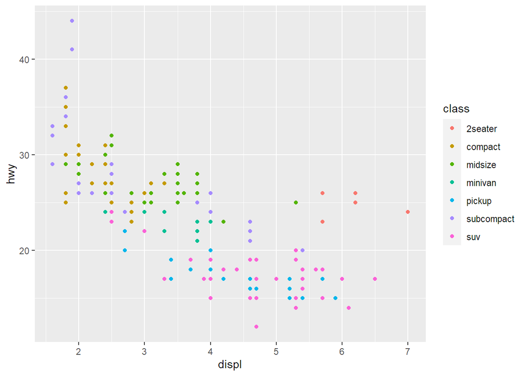

```r
ggplot(data=mpg)+
  geom_point(mapping=aes(x=displ, y=hwy, color=class))
```

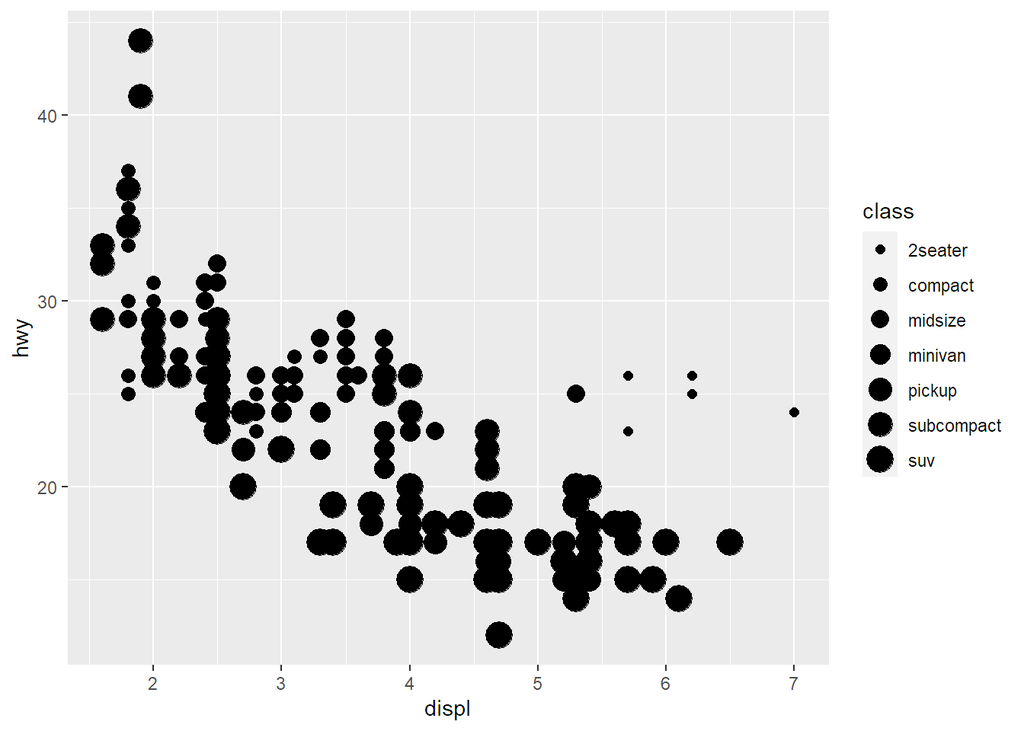

```r
ggplot(data=mpg)+
  geom_point(mapping=aes(x=displ, y=hwy, size=class))
```

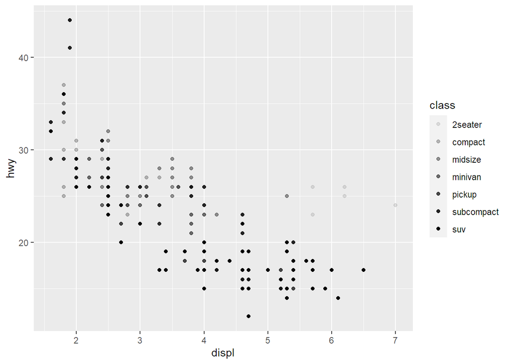

```r
ggplot(data=mpg)+
  geom_point(mapping=aes(x=displ, y=hwy, alpha=class))
```

=> aes(shape) -> class별로 모양을 다르게 할 수 있다.

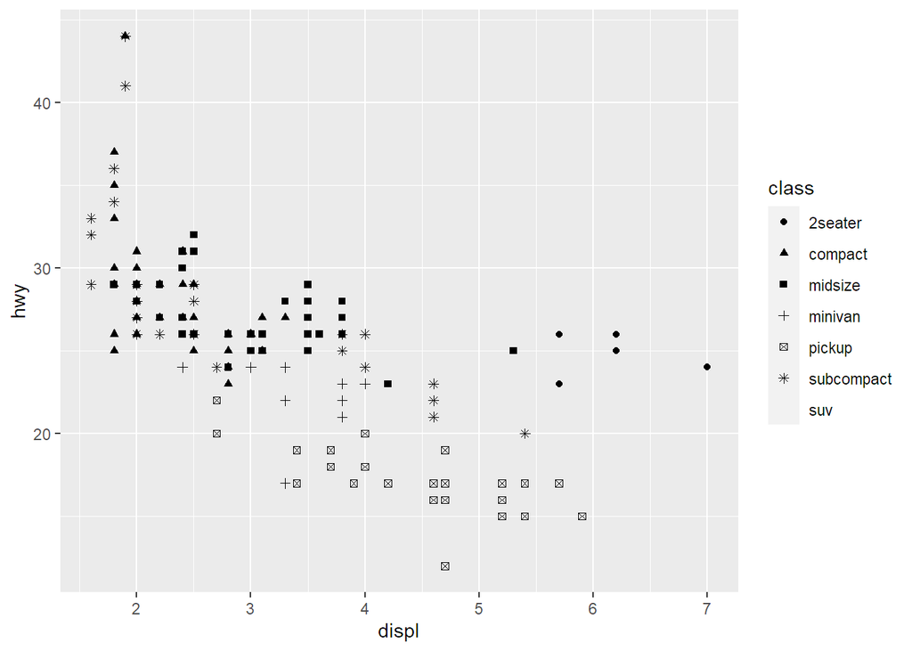

```r
ggplot(data=mpg)+
  geom_point(mapping=aes(x=displ, y=hwy, shape=class))
```

#### mapping_my turn2

1. What goes wrong with this code?  
   :aes(x, y), colour=“blue” - 모든 점을 파란색으로 지정한 것이다.  
   :aes(x, y, colour=“blue”) - aes안에는 변수만 와야하므로 blue라는 변수로 인식-> 무조건 빨간색

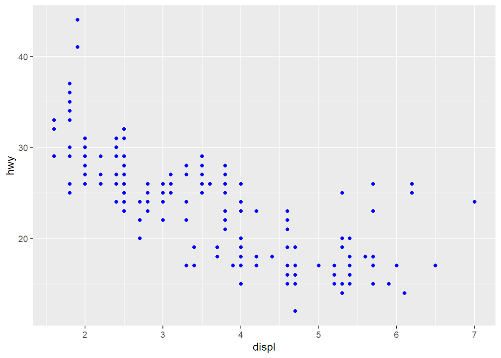

```r
ggplot(data=mpg) +
  geom_point(mapping=aes(x=displ, y=hwy), colour="blue")
```

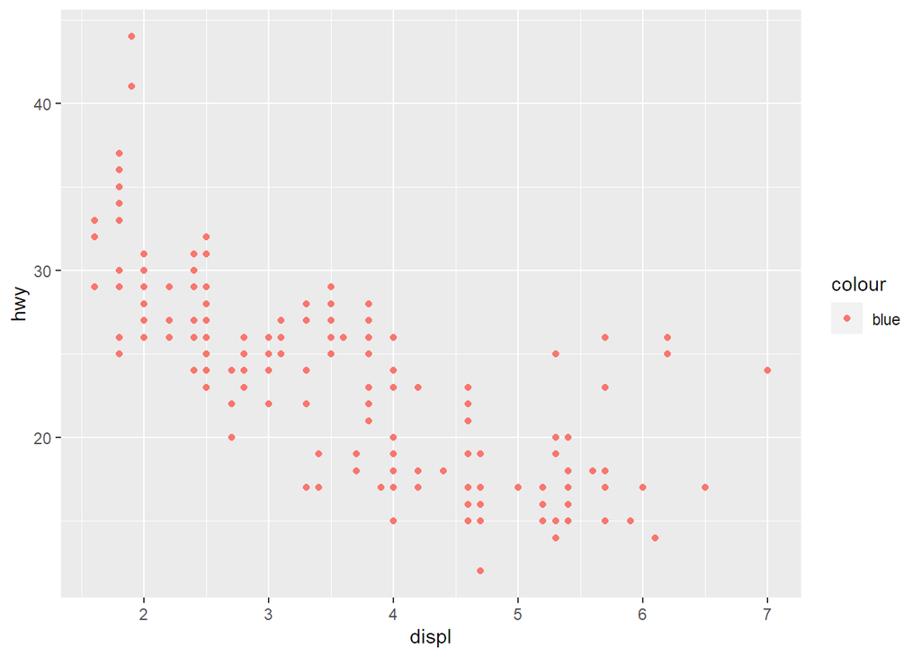

```r
ggplot(data=mpg) +
  geom_point(mapping=aes(x=displ, y=hwy, colour="blue"))
```

2. Which variables in mpg are categorical? Which variables are continuous?  
   :범주형변수 - manufacturer,model, trans,drv, fl,class  
   :연속형변수 - 이외

```r
glimpse(mpg)
```

```
## Rows: 234
## Columns: 11
## $ manufacturer <chr> "audi", "audi", "audi", "audi", "audi", "audi", "audi", "~
## $ model        <chr> "a4", "a4", "a4", "a4", "a4", "a4", "a4", "a4 quattro", "~
## $ displ        <dbl> 1.8, 1.8, 2.0, 2.0, 2.8, 2.8, 3.1, 1.8, 1.8, 2.0, 2.0, 2.~
## $ year         <int> 1999, 1999, 2008, 2008, 1999, 1999, 2008, 1999, 1999, 200~
## $ cyl          <int> 4, 4, 4, 4, 6, 6, 6, 4, 4, 4, 4, 6, 6, 6, 6, 6, 6, 8, 8, ~
## $ trans        <chr> "auto(l5)", "manual(m5)", "manual(m6)", "auto(av)", "auto~
## $ drv          <chr> "f", "f", "f", "f", "f", "f", "f", "4", "4", "4", "4", "4~
## $ cty          <int> 18, 21, 20, 21, 16, 18, 18, 18, 16, 20, 19, 15, 17, 17, 1~
## $ hwy          <int> 29, 29, 31, 30, 26, 26, 27, 26, 25, 28, 27, 25, 25, 25, 2~
## $ fl           <chr> "p", "p", "p", "p", "p", "p", "p", "p", "p", "p", "p", "p~
## $ class        <chr> "compact", "compact", "compact", "compact", "compact", "c~
```

3. **Map a continuous variable to color, size, and shape. How do these aesthetics behave differently for categorical vs. continuous variables?**

   연속형변수를 size, colou로 지정한 경우 부분적으로 범위를 지정하여 표시한다.

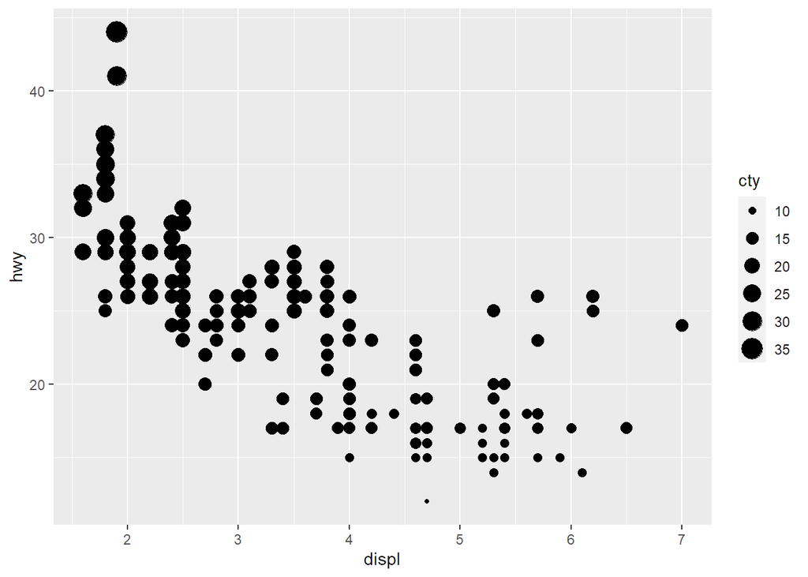

```r
ggplot(data=mpg) +
  geom_point(mapping=aes(x=displ, y=hwy, size=cty))
```

```r
ggplot(data=mpg) +
  geom_point(mapping=aes(x=displ, y=hwy, colour=cty))
```

[output not shown]

하지만, shape으로 지정한 경우 error가 나타난다.

```r
ggplot(data=mpg) +
  geom_point(mapping=aes(x=displ, y=hwy, shape=cty))
```

4. **What happens if you map the same variable to multiple aesthetics?**

   같은 변수는 같은 정보이므로 colour,size 등에 넣을 필요 없다

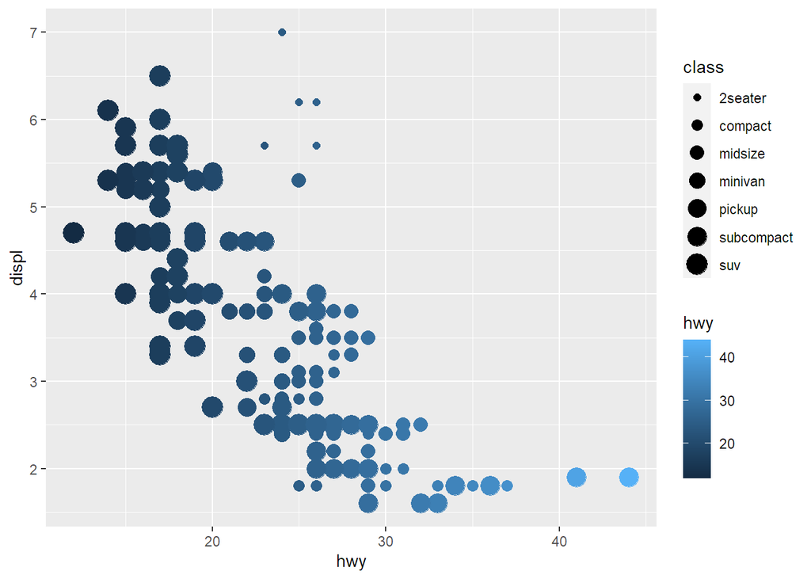

```r
ggplot(data=mpg) +
  geom_point(mapping=aes(x=hwy, y=displ, colour=hwy, size=class))
```

5. **What does the stroke aesthetic do? What shapes does it work with? (Hint: use ?geom_point)**

   stroke : 테두리의 굵기

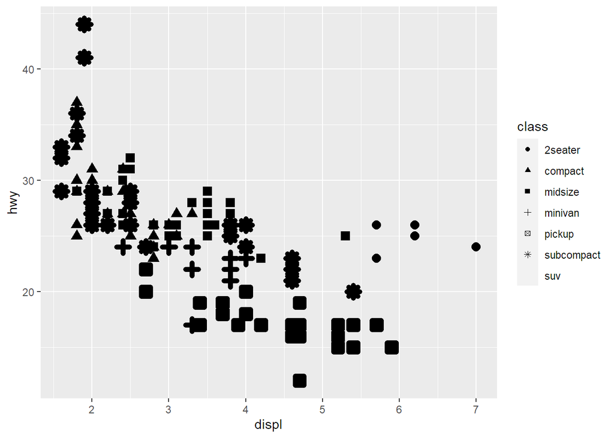

```r
?geom_point
ggplot(data=mpg) +
  geom_point(mapping=aes(x=displ, y=hwy, stroke=3, shape=class))
```

point의 테투리와 테두리 안의 색깔을 따로 지정할 때  
-> shape지정(원:21) : colour(테두리색깔), fill(테두리 안 색깔), size(원의 크기), stroke(테두리 굵기)

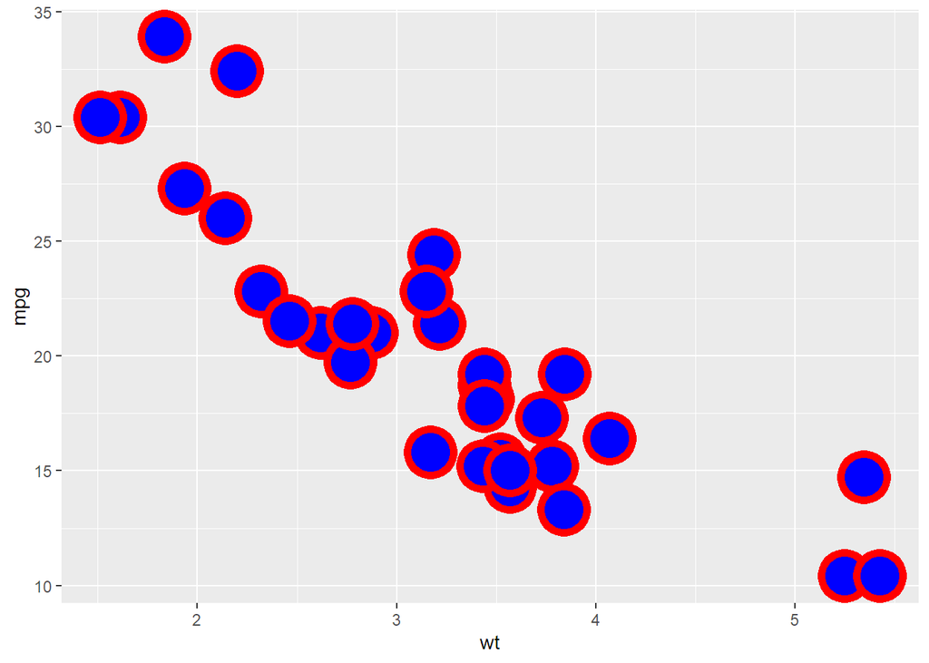

```r
ggplot(mtcars, aes(wt,mpg))+
  geom_point(shape=21, colour="red", fill="blue", size=10, stroke=3)
```

6. **What happens if you map an aesthetic to something other than a variable name, like aes(colour = displ < 5)?**

   연속형범수를 범위를 지정해주어 displ이 5보다 작은 것은 파란색(TRUE), 5보다 큰 것은 빨간색(FALSE)으로 지정할 수 있다.

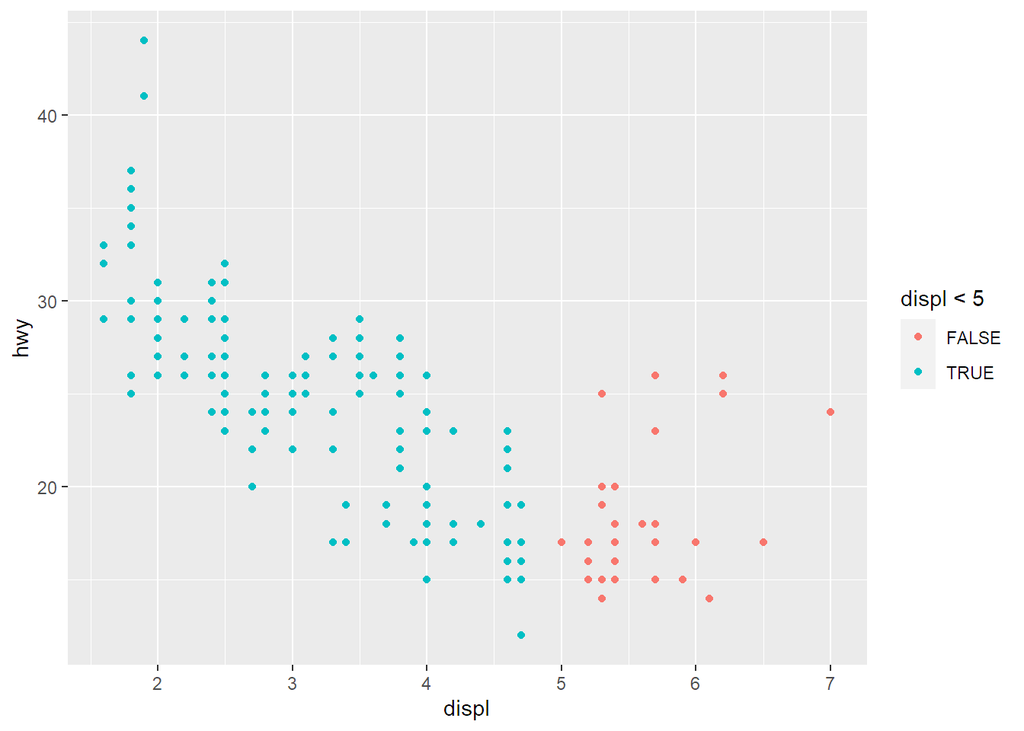

```r
ggplot(data=mpg) +
  geom_point(mapping=aes(x=displ, y=hwy, colour=displ<5))
```

### 3. Facets

- facet_wrap(~범주형변수) : 구분하고자 하는 범주형 변수가 1개일 때, 이를 기준으로 표를 나누어 graph를 보여준다.
- facet_grid(범주형변수1~범주형변수2) : 구분하고자 하는 범주형 변수가 2개일 때

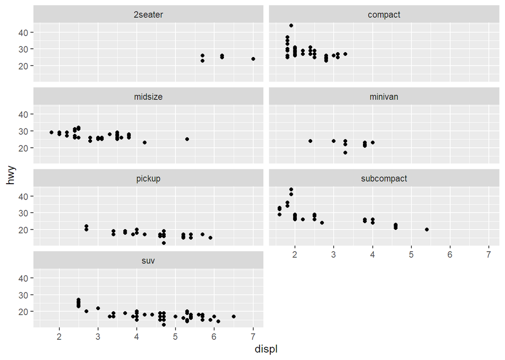

```r
ggplot(data=mpg) +
  geom_point(mapping=aes(x=displ,y=hwy)) +
  facet_wrap(~class,nrow=4)
```

```r
ggplot(data=mpg) +
  geom_point(mapping=aes(x=displ,y=hwy)) +
  facet_grid(drv~cyl)
```

[output not shown]

#### Facets_my turn3

1. **What happens if you facet on a continuous variable?**

   연속형 범수일 때, 숫자를 하나의 범주로 보아 무수히 많은 범주가 생긴다.

   만약 더 큰 데이터였다면 그릴 수 없었을 것이다.

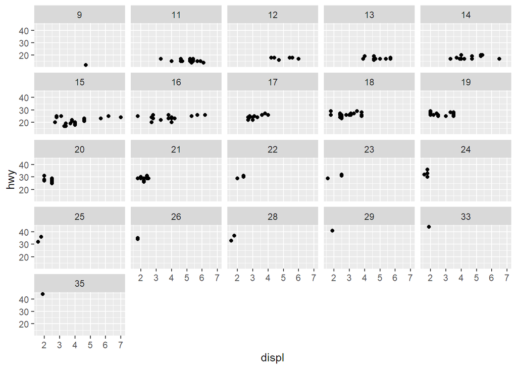

```r
ggplot(data=mpg) +
  geom_point(mapping=aes(x=displ,y=hwy)) +
  facet_wrap(.~cty)
```

2. **What do the empty cells in plot with facet_grid(drv ~ cyl) mean? How do they relate to this plot?**

   빈 셀의 경우, 해당 범주 안에 데이터가 없는 경우이다.

```r
ggplot(data=mpg) +
  geom_point(mapping=aes(x=displ,y=hwy)) +
  facet_grid(drv~cyl)
```

[output not shown]

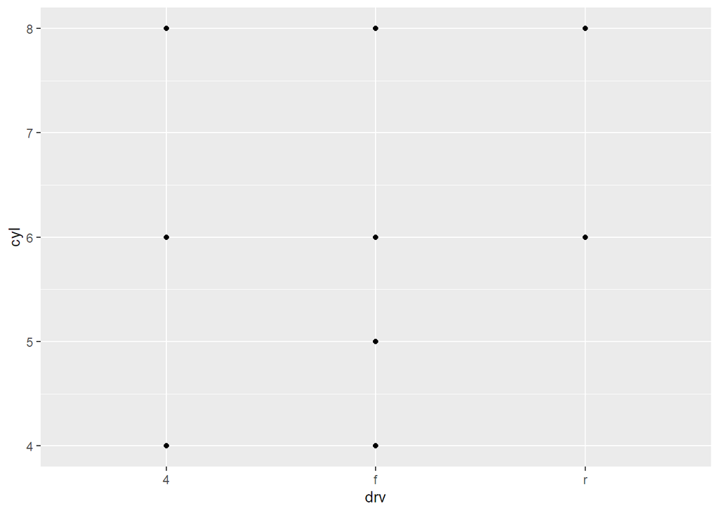

```r
ggplot(data=mpg) +
  geom_point(mapping=aes(x=drv,y=cyl))
```

3. **What plots does the following code make? What does . do?**

   facet_grid(A~.) - 가로로 A 범주 나누어준다.

   facet_grid(.~A) - 세로로 A 범주 나누어준다.

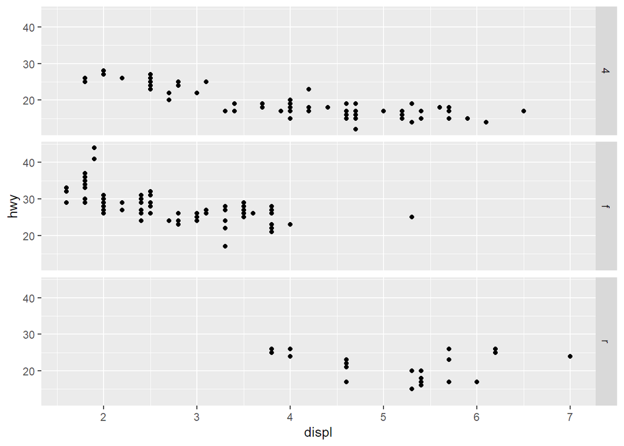

```r
ggplot(data=mpg)+
  geom_point(mapping=aes(x=displ, y=hwy)) +
  facet_grid(drv~.)
```

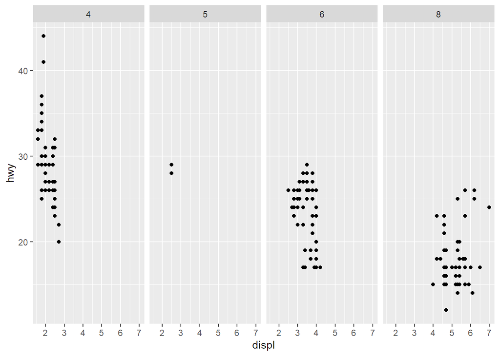

```r
ggplot(data=mpg)+
  geom_point(mapping=aes(x=displ, y=hwy)) +
  facet_grid(.~cyl)
```

4. **What are the advantages to using faceting instead of the colour aesthetic? What are the disadvantages? How might the balance change if you had a larger dataset?**

   facetting - 범주형 분포를 정확히 알 수 있으나, 전체적인 분포를 알기는 어렵다.

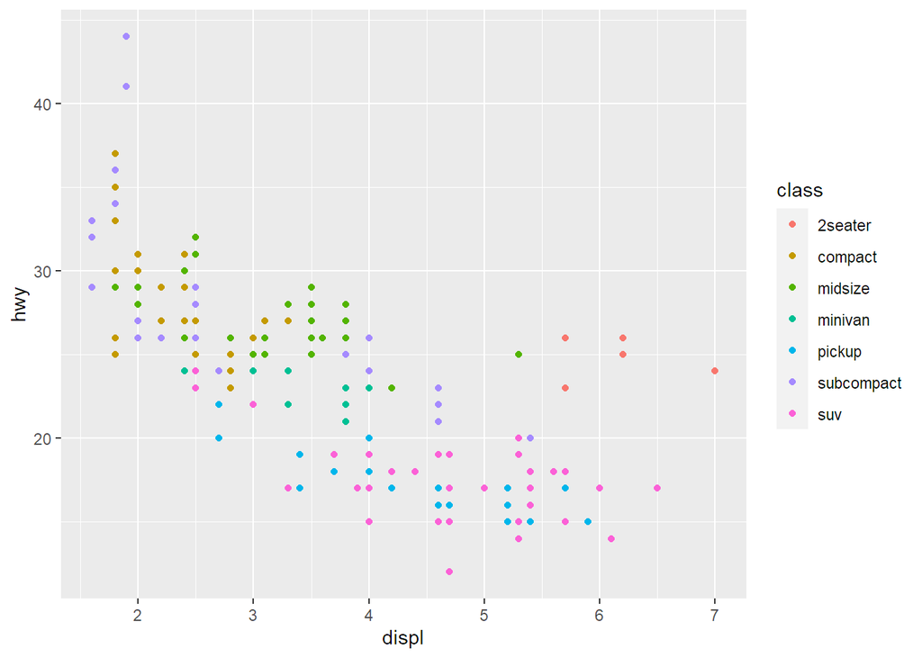

```r
ggplot(data=mpg)+
  geom_point(mapping=aes(x=displ, y=hwy, colour=class))
```

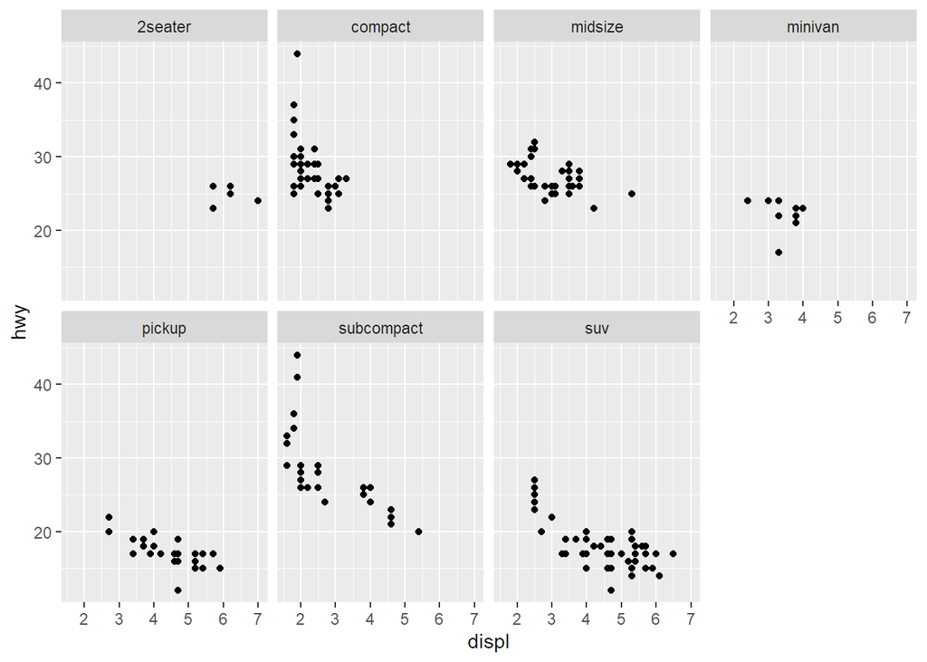

```r
ggplot(data=mpg)+
  geom_point(mapping=aes(x=displ, y=hwy)) +
  facet_wrap(~class, nrow=2)
```

5. Read ?facet_wrap. What does nrow do? What does ncol do? What other options control the layout of the individual panels? Why doesn’t facet_grid() have nrow and ncol arguments?

**[facet_wrap 옵션] : 변수가 1개일 때**

nrow=>행, ncol=>열 -> 지정한 행개수, 열개수로 graph를 나열한다.

**[facet_grid 옵션] : 변수가 2개일 때**

변수가 2개로 하나의 변수는 가로, 또다른 변수는 세로로 지정되어 직접 nrow, ncol을 조정할 수 없어 옵션이 없다.

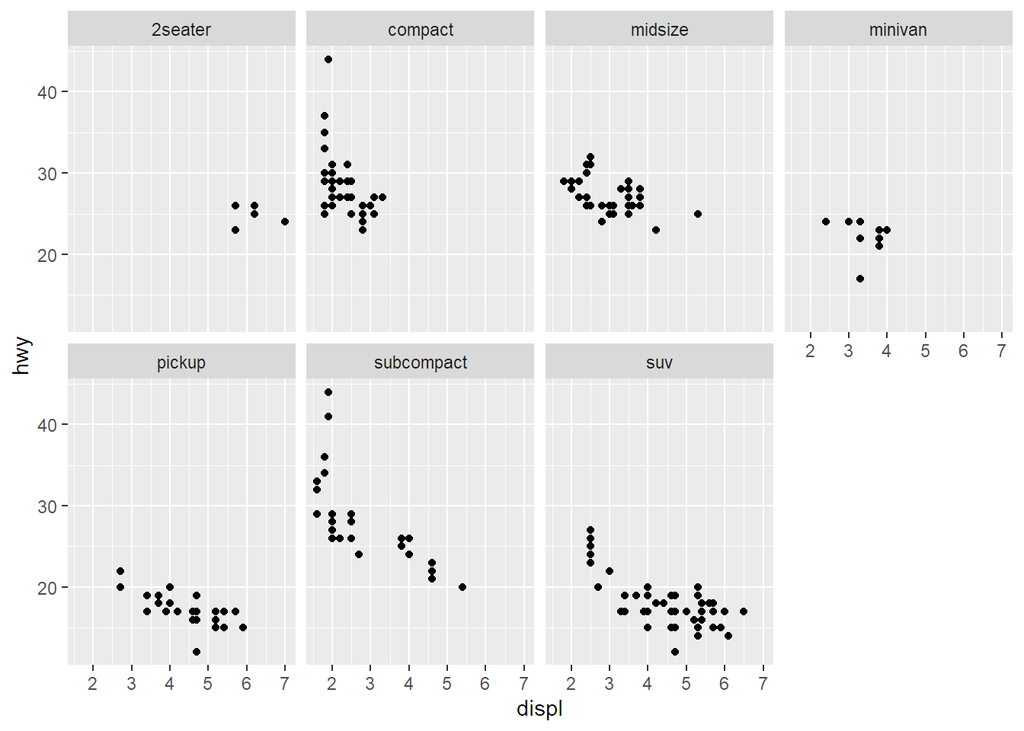

```r
ggplot(data=mpg)+
  geom_point(mapping=aes(x=displ, y=hwy)) +
  facet_wrap(~class, ncol=4)
```

```r
ggplot(data=mpg) +
  geom_point(mapping=aes(x=displ,y=hwy)) +
  facet_grid(drv~cyl)
```

[output not shown]

```r
ggplot(data=mpg)+
  geom_point(mapping=aes(x=displ, y=hwy)) +
  facet_grid(drv~cyl, ncol=4)
```

옵션 scales=“free_y” : 절대적인 비교가 필요없을 경우 y축 범위 최소 최대로 가능

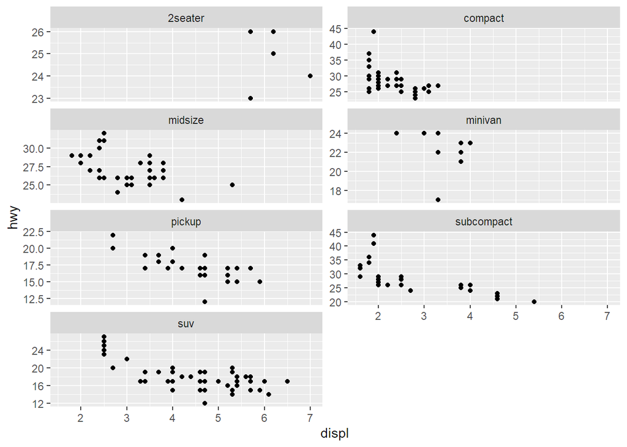

```r
ggplot(data=mpg)+
  geom_point(mapping=aes(x=displ, y=hwy))+
  facet_wrap(~class,nrow=4,scales="free_y")
```

### 4. geom_function(line, point, smooth)

- geom_smooth  
  -> aes(group) : group별로 따로 그래프 작성할 수 있다.  
  -> aes(linetype) : group별로 linetype 설정 -> shapetype은 설정X

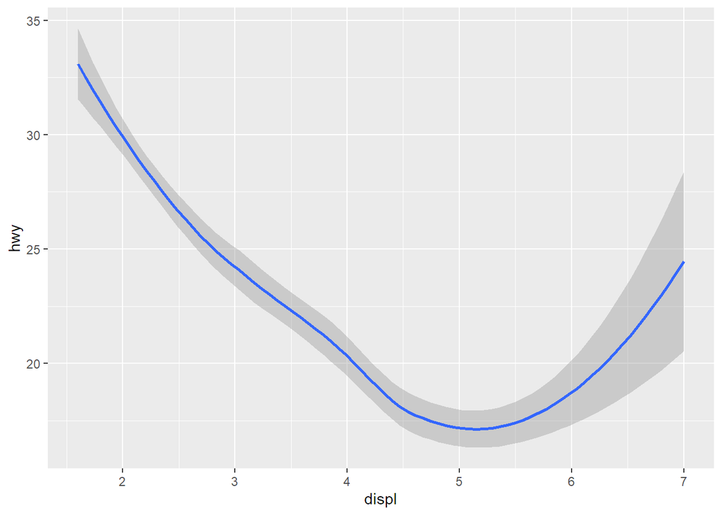

```r
ggplot(data=mpg)+
  geom_smooth(mapping=aes(x=displ,y=hwy))
```

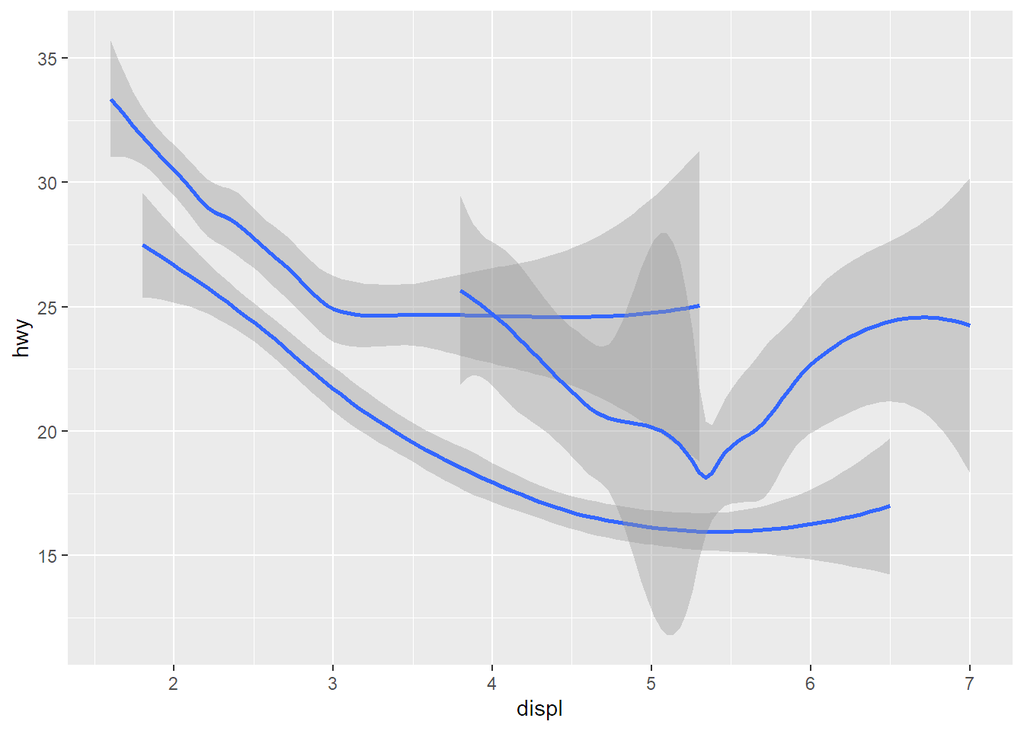

```r
ggplot(data=mpg)+
  geom_smooth(mapping=aes(x=displ,y=hwy, group=drv))
```

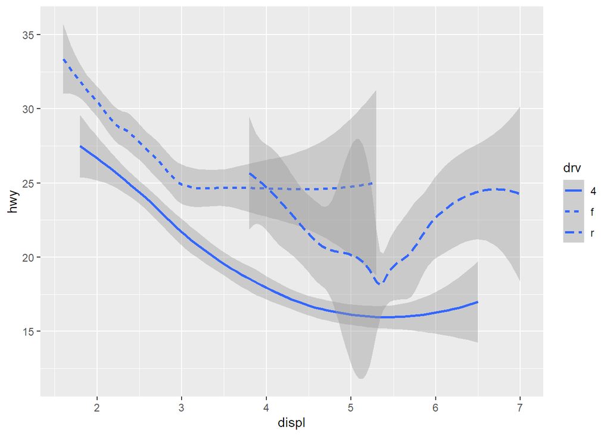

```r
ggplot(data=mpg)+
  geom_smooth(mapping=aes(x=displ,y=hwy, linetype=drv))
```

- geom은 계속해서 추가 가능하다.  
  -> ggplot(mapping=aes(x,y)) : 추가되는 모든 geom function이 같은 x, y 변수 및 특징을 가진다.  
  -> ggplot() + geom(mappin=aes(x,y)) : 추가되는 geom function에 다른 x, y 변수를 가질 수 있도록 한다.  
  : filter을 이용하여 data의 일부만 선택하여 지정할 수도 있다.

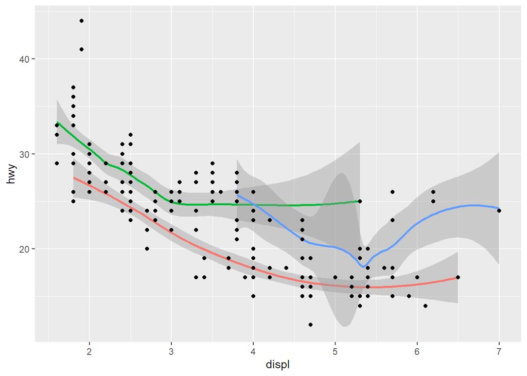

```r
ggplot(data=mpg)+
  geom_smooth(mapping=aes(x=displ,y=hwy, color=drv), show.legend=F) +
  geom_point(aes(x=displ,y=hwy))
```

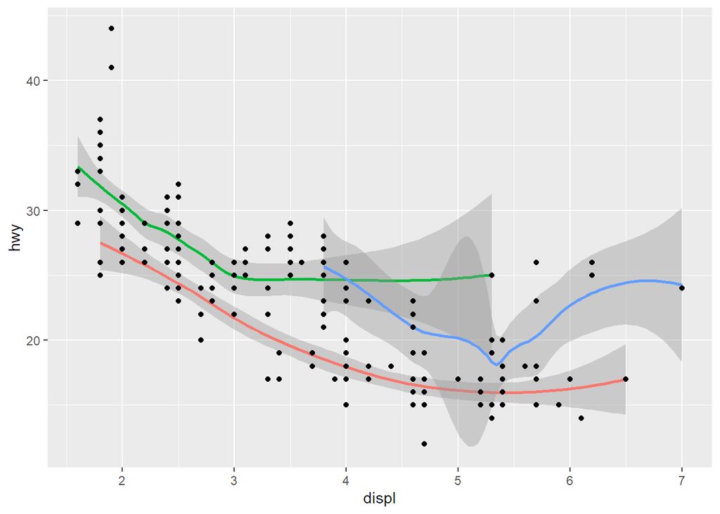

```r
ggplot(data=mpg, mapping=aes(x=displ,y=hwy))+
  geom_smooth(aes(color=drv), show.legend=F) +
  geom_point()
```

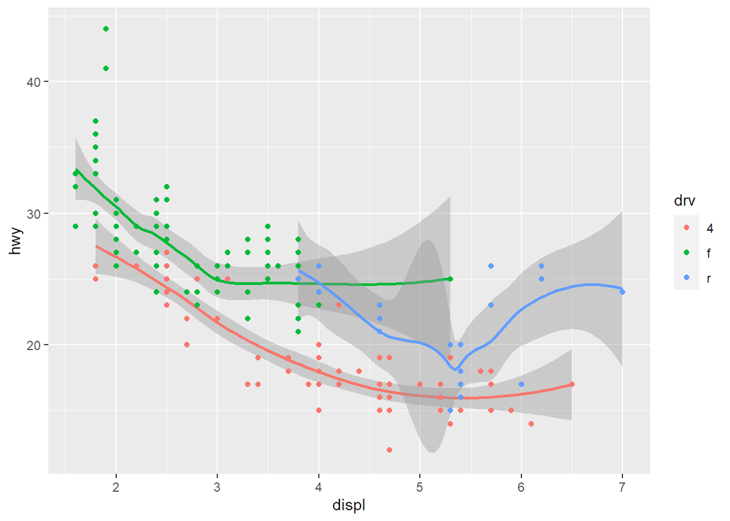

```r
ggplot(data=mpg, mapping=aes(x=displ,y=hwy, color=drv))+
  geom_smooth(show.legend=F) +
  geom_point()
```

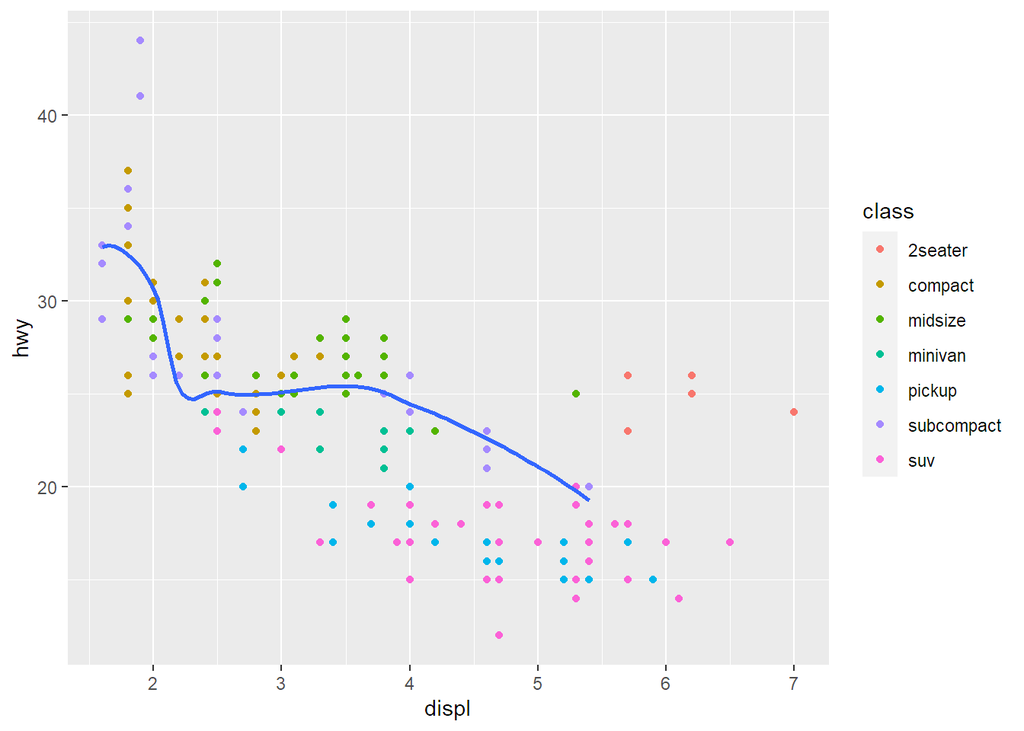

```r
#data의 일부만 선택하는 경우
ggplot(data=mpg,mapping=aes(x=displ,y=hwy))+
  geom_point(mapping=aes(color=class))+
  geom_smooth(data=filter(mpg, class=="subcompact"), se=FALSE)
```